# Modern concepts and methods in Macroecology and Biogeography

Day 6: Island Biogeography

Patrick Weigelt, Pierre Denelle & Holger Kreft

May 22nd, 2024

*back to overview*

**Preparation:** Open your RStudio project and download new data for today from [Stud-IP](https://studip.uni-goettingen.de/dispatch.php/course/files/index/74501b33f332a6d238443bfbd502cc6c?cid=1746ae3fe971afbf90b74e3d64389586) (log in first) and unzip them into your project folder ’/data/. You can use `getwd()` to locate your current working directory, which should be your project folder. Please install the following R-packages using `install.packages()`:

- maps
- classInt
- psych
- car
- lme4
- jtools
- performance
- ggplot2
- sf
- GGally
- rnaturalearth
- rnaturalearthdata
- ggpmisc
- cowplot
- dplyr
- tidyr
- GIFT

If you want to visualize this tutorial in the viewer inside RStudio (to save space on your screen) run the following chunk of code:

```r
install.packages("rstudioapi") # install an R-package required for this step
dir <- tempfile()
dir.create(dir)
download.file("https://gift.uni-goettingen.de/mcmmb/index.html", destfile = file.path(dir, "index.html"))
download.file("https://gift.uni-goettingen.de/mcmmb/Day6.html", destfile = file.path(dir, "Day6.html"))
htmlFile <- file.path(dir, "Day6.html")
rstudioapi::viewer(htmlFile)
```

Now you can conveniently copy code from the viewer into your script.

**Load R packages & island data set**

```r
library(maps)
library(classInt)
data(worldMapEnv)
library(psych)
library(car)
library(lme4)
library(jtools)
library(performance)
library(ggplot2)
library(GGally)
library(sf)
library(rnaturalearth)
library(rnaturalearthdata)
library(ggpmisc)
library(cowplot)
library(dplyr)
library(tidyr)
library(GIFT)
```

# 1. Data extraction & exploration

## 1.1. Data extraction from GIFT database

We will download island-level angiosperm species richness and environmental data from the [GIFT](https://gift.uni-goettingen.de/home) database ([Weigelt et al. 2020](https://onlinelibrary.wiley.com/doi/10.1111/jbi.13623)) using the [GIFT R-package](https://biogeomacro.github.io/GIFT/).

```r
# Islands in GIFT
islands <- GIFT_regions(GIFT_version = "2.1")
islands <- islands[which(islands$suit_geo == 1 & islands$entity_class == "Island"),
                   c("entity_ID", "geo_entity")]

# Geographic characteristics
islands_geo <- GIFT_env(entity_ID = islands$entity_ID,
                        miscellaneous = c("longitude","latitude","area","dist"),
                        GIFT_version = "2.1")
islands_geo$geo_entity <- NULL

islands <- inner_join(islands, islands_geo, by="entity_ID")

# Island geology
islands_geology <- read.csv("data/islands_geology.csv")

islands <- inner_join(islands, islands_geology, by="entity_ID")

# Angiosperm species richness
islands_richness <- GIFT_richness(taxon_name = "Angiospermae", GIFT_version = "2.1")
islands_richness <- islands_richness[!is.na(islands_richness$native),
                                     c("entity_ID","native","endemic_min")]
names(islands_richness) <- c("entity_ID","spec_num","end_num")

islands <- inner_join(islands, islands_richness, by="entity_ID")

# Environmental data
islands_env <- GIFT_env(entity_ID = islands$entity_ID,
                        rasterlayer = c("mx30_grd", "CHELSA_bio10_1",
                                       "CHELSA_bio10_12", "Homogeneity_01_05_1km_uint16"),
                        sumstat = list("max","mean","mean","mean"),
                        GIFT_version = "2.1")

names(islands_env) <- c("entity_ID", "geo_entity", "max_elev", "mean_temp", "mean_prec", "mean_homogeneity")
islands_env$geo_entity <- NULL

islands <- inner_join(islands, islands_env, by="entity_ID")
str(islands)
```

```
## 'data.frame':    1068 obs. of  14 variables:
##  $ entity_ID       : num  1 2 3 4 5 6 7 8 9 10 ...
##  $ geo_entity      : chr  "Ashmore Reef" "Cartier Island" "Christmas Island" "Coral Sea Islands Territory" ...
##  $ longitude       : num  123 124 106 152 114 ...
##  $ latitude        : num  -12.3 -12.5 -10.5 -19 -28.5 ...
##  $ area            : num  17.836 0.0499 139.6099 3.9508 5.9764 ...
##  $ dist            : num  344.7 290.4 1309.6 315.4 59.1 ...
##  $ age_MA          : num  NA NA 20 NA NA NA NA NA NA NA ...
##  $ geology         : chr  "shelf" "shelf" "volcanic" "atoll" ...
##  $ spec_num        : num  23 1 200 21 72 7 21 1 1 2 ...
##  $ end_num         : num  0 0 15 0 NA NA NA NA NA NA ...
##  $ max_elev        : num  12 4 367 18 16 0 10 0 0 0 ...
##  $ mean_temp       : num  27.9 27.9 25.4 24 20.8 ...
##  $ mean_prec       : num  1395 1383 2178 1085 441 ...
##  $ mean_homogeneity: num  0.296 NA 0.301 NA 0.227 ...
```

```r
# write.csv(islands, "data/islands.csv", row.names = FALSE)
# islands <- read.csv("data/islands.csv")
```

## 1.2. Map species richness

With ggplot2

```r
# World coastlines
world <- ne_coastline(scale = "medium", returnclass = "sf")
class(world)
```

```
## [1] "sf"         "data.frame"
```

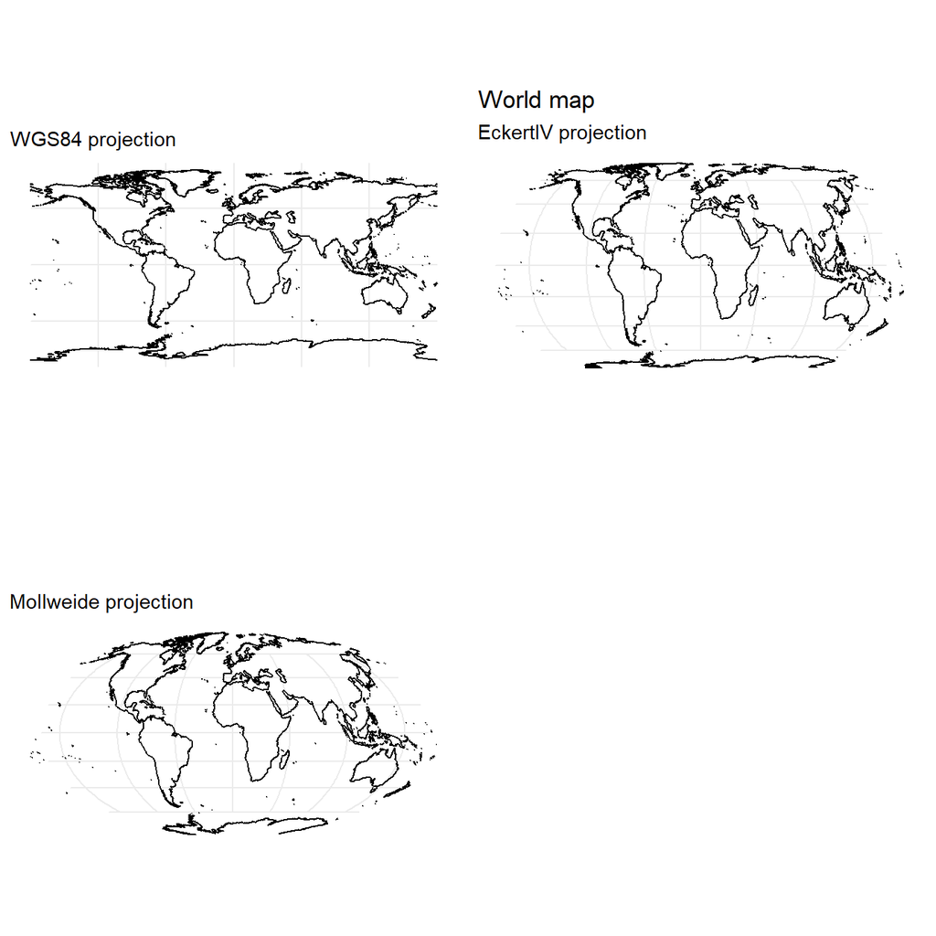

```r
# Other projections
eckertIV <- "+proj=eck4 +lon_0=0 +x_0=0 +y_0=0 +ellps=WGS84 +datum=WGS84 +units=m +no_defs"
mollweide <- "+proj=moll +lon_0=0 +x_0=0 +y_0=0 +datum=WGS84 +units=m +no_defs "
# https://semba-blog.netlify.app/01/26/2020/world-map-and-map-projections/

# Links regarding the choice of projections
# http://www.geography.hunter.cuny.edu/~jochen/gtech361/lectures/lecture04/concepts/Map%20coordinate%20systems/Map%20projections%20and%20distortion.htm
# http://www.geo.hunter.cuny.edu/~jochen/gtech201/lectures/lec6concepts/map%20coordinate%20systems/how%20to%20choose%20a%20projection.htm

plot_grid(
  ggplot(world) +
    geom_sf() +
    labs(title = "",
         subtitle = "WGS84 projection") +
    theme_bw() +
    theme(panel.border = element_blank()),
  ggplot(world) +
    geom_sf() +
    coord_sf(crs = eckertIV) +
    labs(title = "World map",
         subtitle = "EckertIV projection") +
    theme_bw() +
    theme(panel.border = element_blank()),
  ggplot(world) +
    geom_sf() +
    coord_sf(crs = mollweide) +
    labs(title = "",
         subtitle = "Mollweide projection") +
    theme_bw() +
    theme(panel.border = element_blank()),
  nrow = 2)
```

To combine the islands data.frame with the world map, we first need to convert it to an *sf* object.

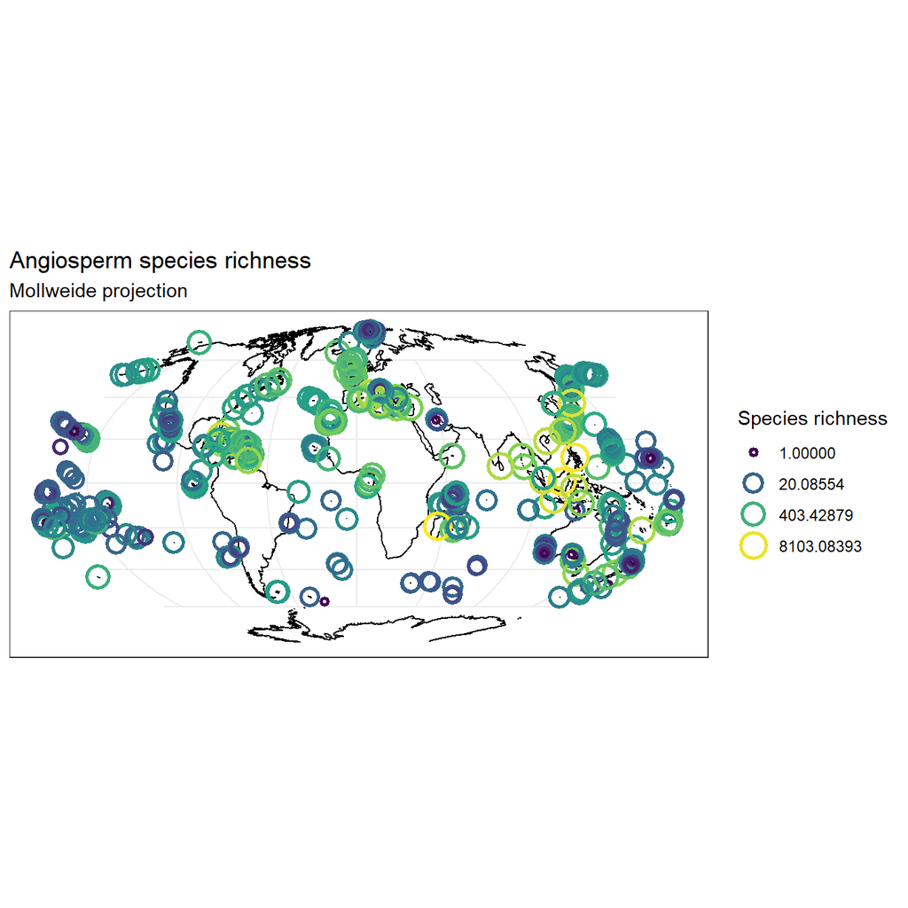

```r
# Convert islands to sf object
islands_sf <- st_as_sf(islands, coords = c("longitude", "latitude"),
                       crs = "+proj=longlat +ellps=WGS84 +no_defs")

# Map
ggplot(world) +
  geom_sf() +
  geom_sf(data = islands_sf, shape = 1, stroke = 1.5,
          aes(size = spec_num, color = spec_num)) +
  scale_color_viridis_c("Species richness", trans = "log", guide = "legend") +
  scale_size_continuous("Species richness", trans = "log") +
  coord_sf(crs = mollweide) + # coord_sf(crs = eckertIV) +
  labs(title = "Angiosperm species richness",
       subtitle = "Mollweide projection") +
  theme_bw()
```

```r
# https://community.rstudio.com/t/ggplot2-is-it-possible-to-combine-color-fill-and-size-legends/17072
```

*Bonus: custom discrete color scale*

**Bonus**

```r
# Arrange islands by species richness (low to high)
islands <- islands[order(islands$spec_num), ]

# create colour gradient
my.class.fr.S <- classIntervals(
  islands$spec_num, n = 9, style = "fixed",
  fixedBreaks = c(0, 25, 50, 100, 200, 400, 800, 1600, 3200, 6400)) # bin data into n quantiles
my.pal <- c("midnightblue", "dodgerblue4", "dodgerblue2", "chartreuse4",
            "gold", "orangered1", "darkred")
my.col.fr.S <- findColours(my.class.fr.S, my.pal) # ramp colors based on classInts
my.col.fr.S[islands$spec_num < 1] <- "#666666" # assign grey for zero species

# specify dimensions of plot for saving
if(.Platform$OS.type == "windows"){
  windows(width=20*0.3937008, height=12*0.3937008)
}else{
  X11(width=20*0.3937008, height=12*0.3937008,type="cairo")
}
# quartz(width=20*0.3937008, height=12*0.3937008) # for Mac

map("world", fill = FALSE)
title(main = "Angiosperm species richness")
points(islands$longitude, islands$latitude,
       pch=ifelse(islands$spec_num >= 1,1,4),
       cex = (log10(islands$spec_num+1)/2.6)^2+1, col = my.col.fr.S, lwd=2)

if(.Platform$OS.type == "windows"){
  savePlot("data/islands.pdf", type = "pdf")
}else{
  dev.copy2pdf(file = "data/islands.pdf")
}

# quartz.save("Data/islands.pdf", type = "pdf") # for Mac
dev.off()
```

## 1.3. Correlations among biogeographic & environmental variables

*Meta-data*  
1. **latitude**: Latitude (in decimal degrees)  
2. **area**: Island area (in km<sup>2</sup>)  
3. **dist**: Distance to the nearest continent (in km)  
4. **age_MA**: Island geological age (million years)  
5. **max_elev**: Maximum elevation (m)  
6. **mean_temp**: Mean annual temperature (degrees Celsius)  
7. **mean_prec**: Mean annual precipitation (mm yr<sup>-1</sup>)  
8. **mean_homogeneity**: Habitat heterogeneity (similarity of vegetation index with surrounding pixels)

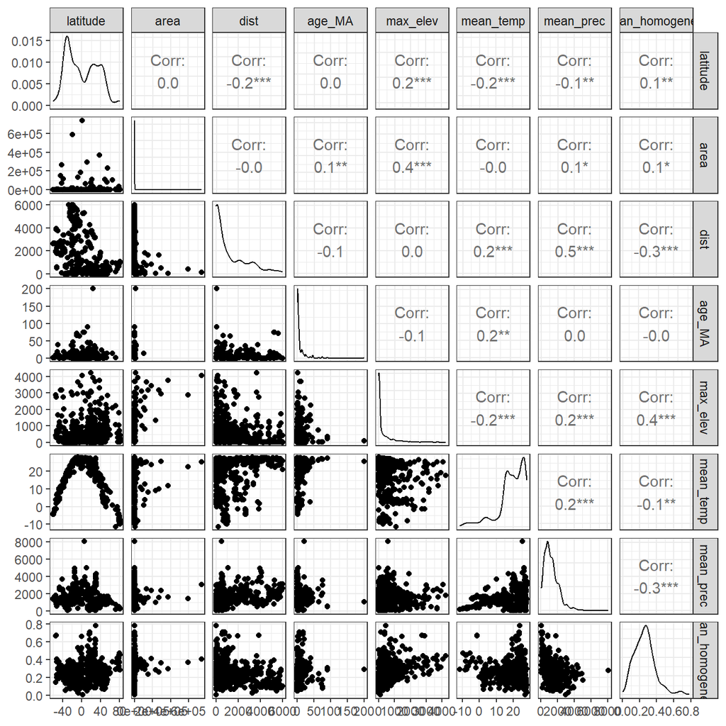

```r
abiotic <- c("latitude", "area", "dist", "age_MA", "max_elev",
             "mean_temp", "mean_prec", "mean_homogeneity")

ggpairs(islands[, abiotic],
        upper = list(continuous = wrap(ggally_cor, digits = 1))) +
  theme_bw()

# Other way to have a pair plot:
# pairs.panels(islands[, c(4:7, 11:14)],
#              density = FALSE, ellipses = FALSE,
#              hist.col = "white")
```

# 2. The species area relationship (SAR)

We here aim at linking, using the best model, island area and plant species richness.

## a) Linear model

*Species Richness ~ Area*

```r
SAR0 <- lm(spec_num ~ area, data = islands)
summary(SAR0)
```

```
##
## Call:
## lm(formula = spec_num ~ area, data = islands)
##
## Residuals:
##     Min      1Q  Median      3Q     Max
## -2659.4  -150.1  -121.6   -23.7  4186.3
##
## Coefficients:
##              Estimate Std. Error t value Pr(>|t|)
## (Intercept) 1.601e+02  1.368e+01   11.70   <2e-16 ***
## area        1.670e-02  3.781e-04   44.16   <2e-16 ***
## ---
## Signif. codes:  0 '***' 0.001 '**' 0.01 '*' 0.05 '.' 0.1 ' ' 1
##
## Residual standard error: 444.6 on 1066 degrees of freedom
## Multiple R-squared:  0.6466, Adjusted R-squared:  0.6463
## F-statistic:  1951 on 1 and 1066 DF,  p-value: < 2.2e-16
```

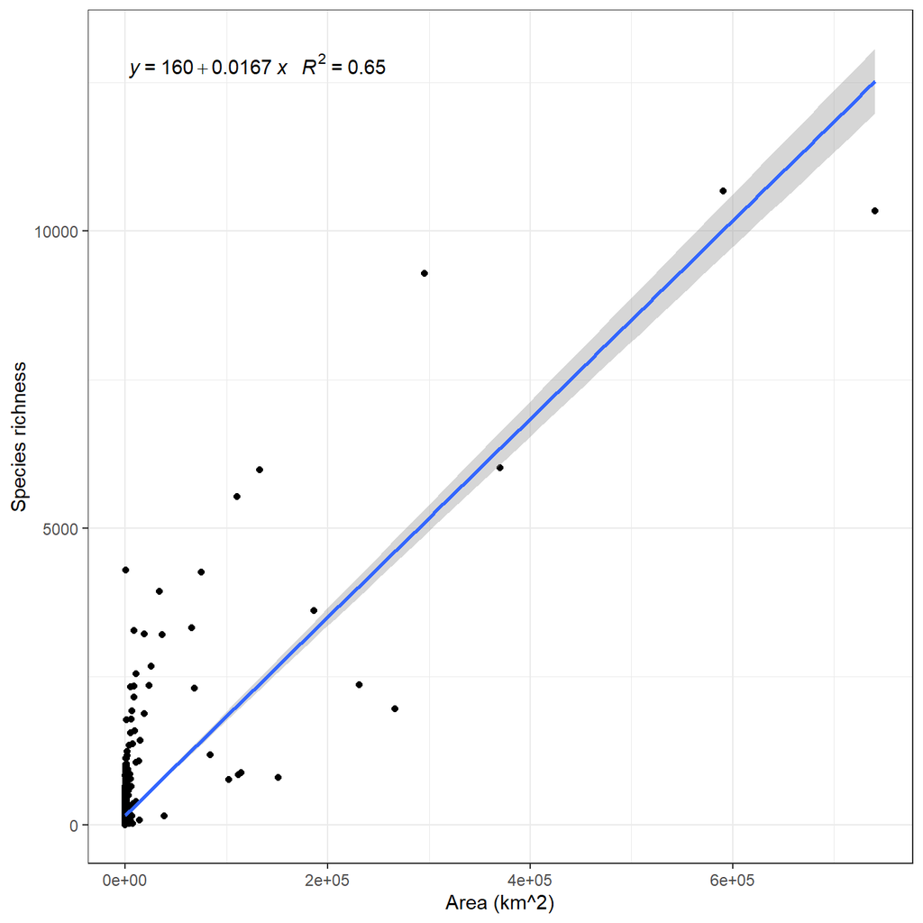

```r
ggplot(islands, aes(area, spec_num)) +
  geom_point() +
  stat_smooth(method = "lm") +
  stat_poly_eq(method = "lm", formula = y ~ x,
               aes(label = paste(..eq.label.., ..rr.label.., sep = "~~~"))) +
  labs(x = "Area (km^2)", y = "Species richness") +
  theme_bw()
```

```r
# plot(spec_num ~ area, data = islands)
# car::regLine(SAR0, col = "darkgreen")
```

## b) Non-linear model

*Species richness ~ c + Area<sup>z</sup>*

```r
SAR1 <- nls(spec_num ~ c + area^z, data = islands,
            start = list(c = 0, z = 1))
summary(SAR1)
```

```
##
## Formula: spec_num ~ c + area^z
##
## Parameters:
##    Estimate Std. Error t value Pr(>|t|)
## c 1.256e+02  1.252e+01   10.03   <2e-16 ***
## z 6.854e-01  1.565e-03  437.92   <2e-16 ***
## ---
## Signif. codes:  0 '***' 0.001 '**' 0.01 '*' 0.05 '.' 0.1 ' ' 1
##
## Residual standard error: 405.3 on 1066 degrees of freedom
##
## Number of iterations to convergence: 8
## Achieved convergence tolerance: 1.19e-07
```

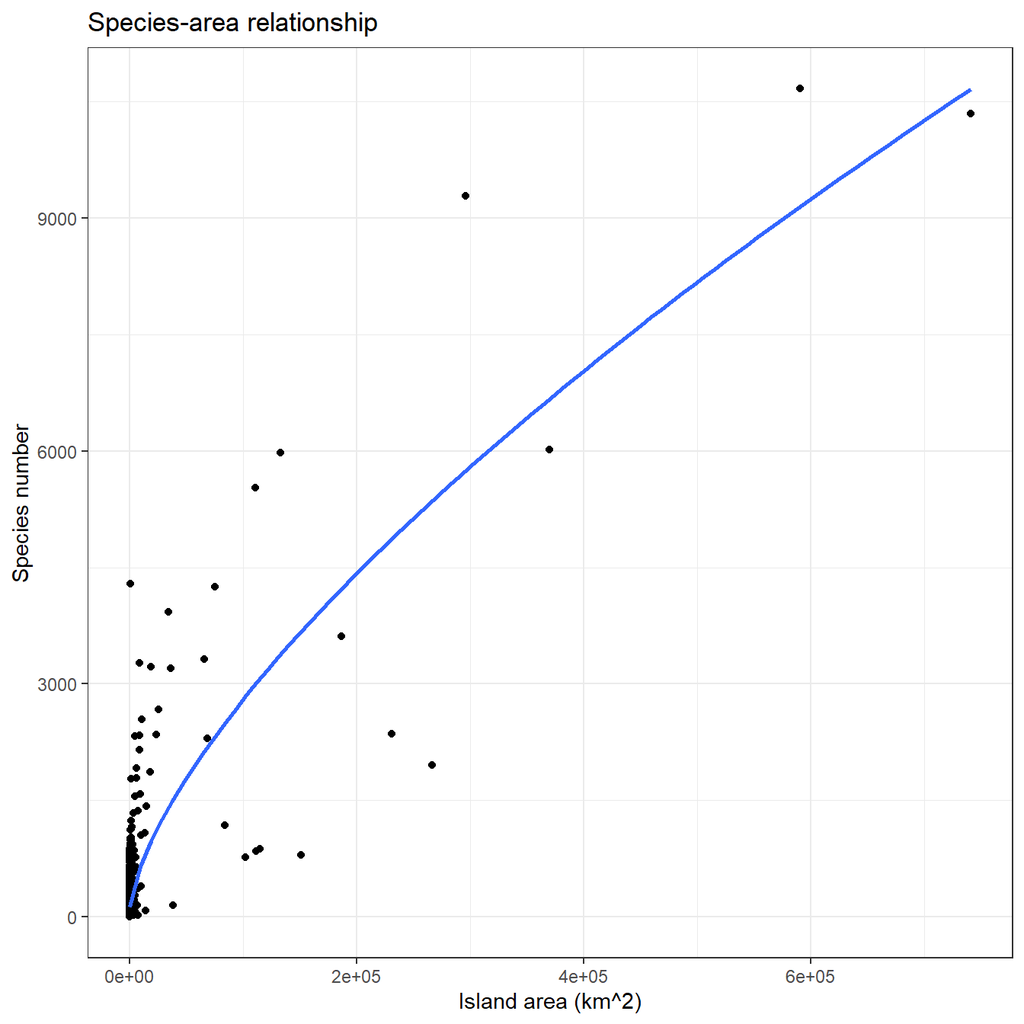

```r
ggplot(islands, aes(area, spec_num)) +
  geom_point() +
  geom_smooth(method = "nls",
              formula = y ~ c + x^z,
              method.args = list(start = c(c = 0, z = 1)),
              se = FALSE) +
  labs(title = "Species-area relationship",
       x = "Island area (km^2)", y = "Species number") +
  theme_bw()
```

```r
# Predictions
newdata <- data.frame(area = seq(min(islands$area), max(islands$area),
                                 length.out = 100))
predicted_richness_SAR1 <- predict(SAR1, newdata = newdata)
head(predicted_richness_SAR1)
```

```
## [1]  125.5888  577.4786  852.2704 1085.0528 1294.1615 1487.2630
```

```r
# plot(islands$area, islands$spec_num, xlab = "Island area (km)",
#      ylab = "Species number", main = "Species-area relationship")
# points(newdata$area, predicted_richness_SAR1, type = "l",
#        col = "darkred", lwd = 2)
```

## c) Exercise I

1. Make histograms of species richness and area
2. Apply a log10 transformation to species richness and area, make new columns of the transformed variables, and plot histograms of them
3. Fit a linear model to log predict species richness using log area
4. Make a plot of the results

**Exercise I solutions:**

*Make histograms of species richness and area*

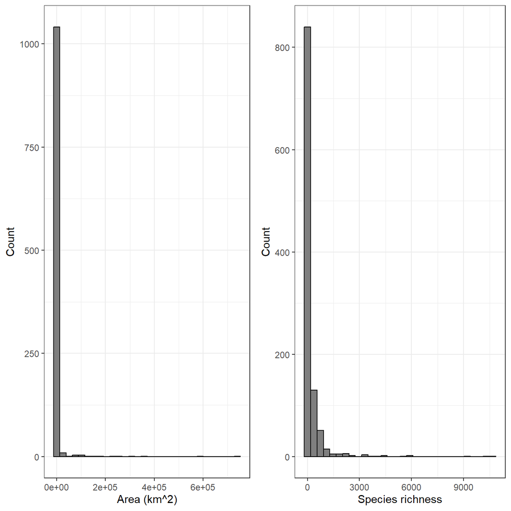

*Apply a log10 transformation to species richness and area, make new columns of the transformed variables in islands data.frame, and plot histograms of them*  
*&*  
*Fit a linear model to predict species richness using area*

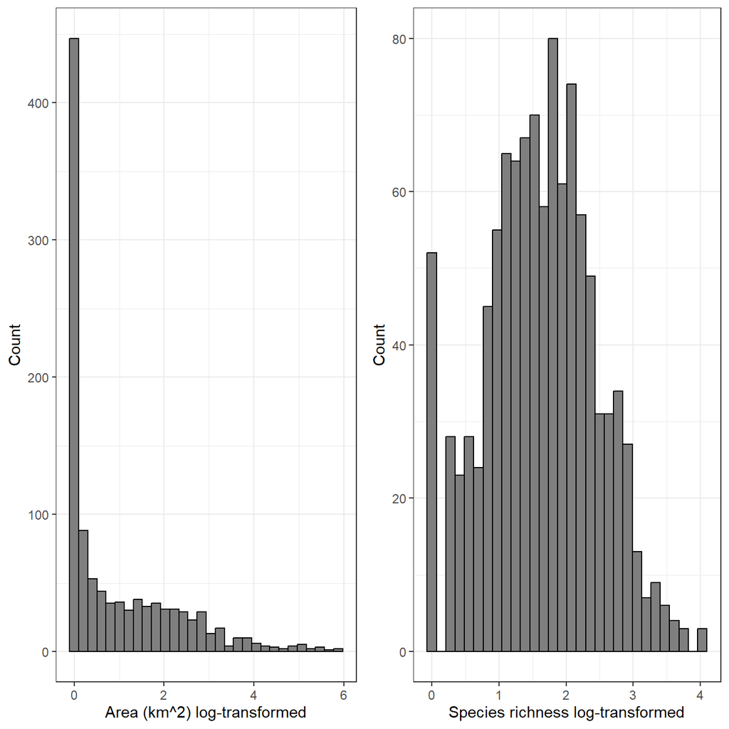

```
##
## Call:
## lm(formula = log_spec_num ~ log_area, data = islands)
##
## Residuals:
##      Min       1Q   Median       3Q      Max
## -2.13829 -0.32555  0.05655  0.41166  1.33863
##
## Coefficients:
##             Estimate Std. Error t value Pr(>|t|)
## (Intercept)  1.16570    0.02169   53.74   <2e-16 ***
## log_area     0.47737    0.01389   34.37   <2e-16 ***
## ---
## Signif. codes:  0 '***' 0.001 '**' 0.01 '*' 0.05 '.' 0.1 ' ' 1
##
## Residual standard error: 0.5602 on 1066 degrees of freedom
## Multiple R-squared:  0.5256, Adjusted R-squared:  0.5252
## F-statistic:  1181 on 1 and 1066 DF,  p-value: < 2.2e-16
```

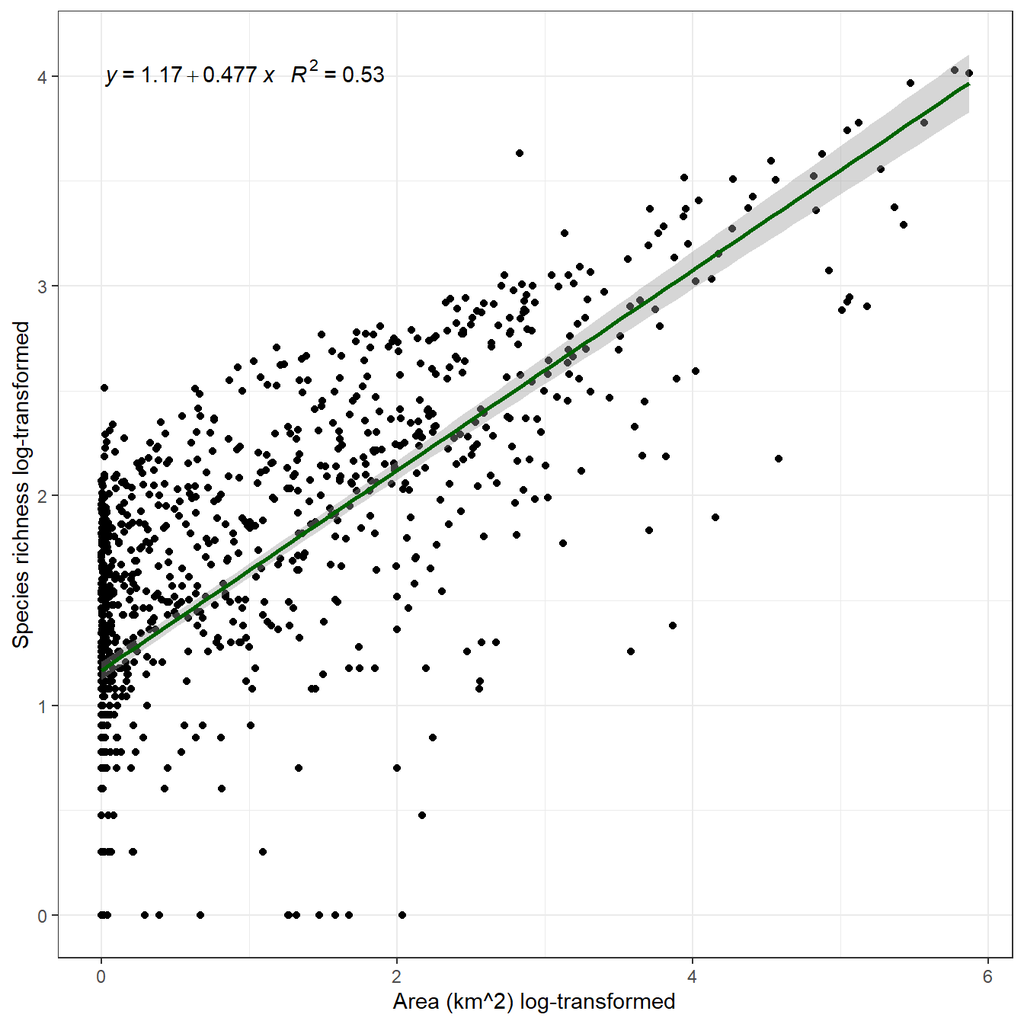

**Check model assumptions**

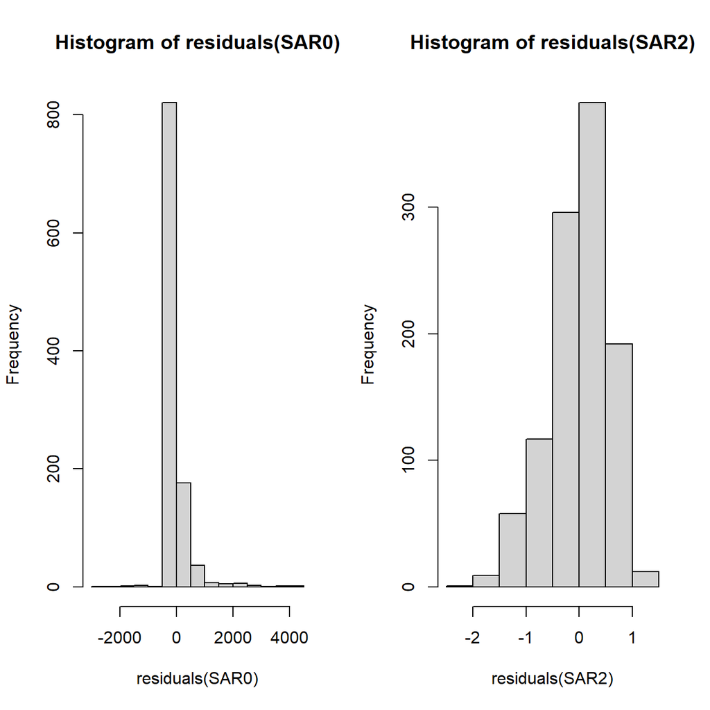

## d) Poisson generalised linear model (GLM)

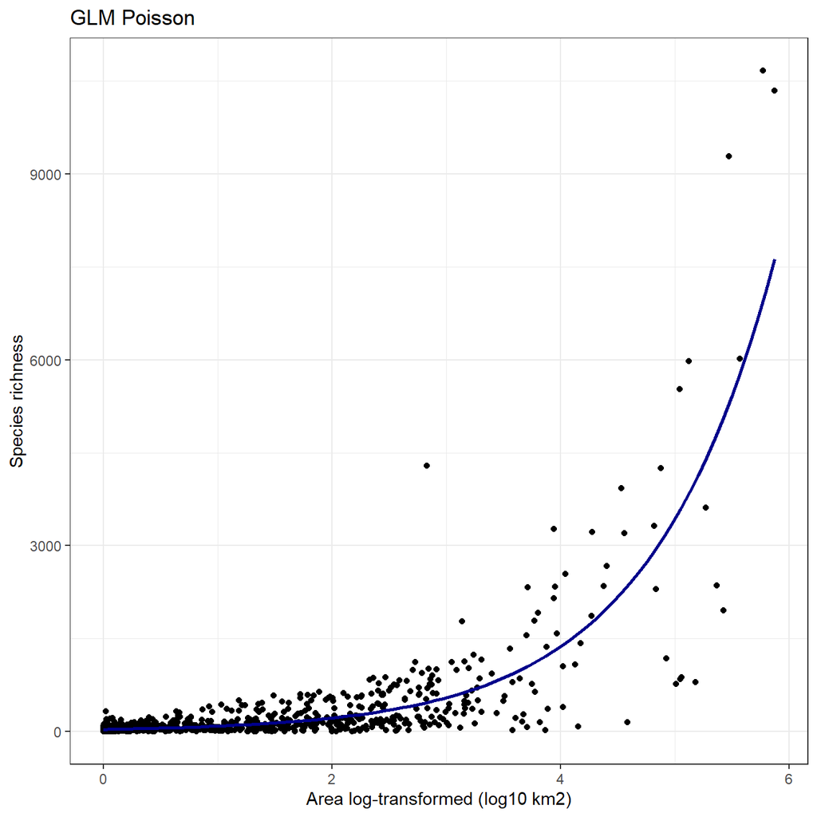

```r
SAR3 <- glm(spec_num ~ log_area, data = islands, family = "poisson")

# 100*(161367-43825)/161367

# Plot Poisson GLM
ggplot(islands, aes(log_area, spec_num)) +
  geom_point() +
  geom_smooth(method = "glm", formula = y ~ x,
              method.args = list(family = "poisson"),
              color = "darkblue") +
  labs(title = "GLM Poisson",
       x = "Area log-transformed (log10 km2)",
       y = "Species richness") +
  theme_bw()
```

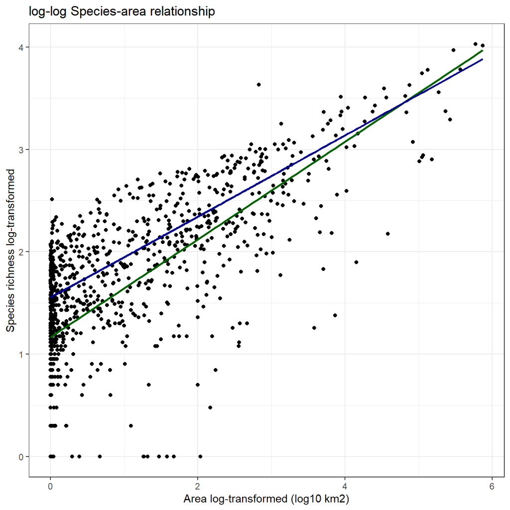

```r
# Plot Poisson GLM in log-log space
newdata_SAR3 <- data.frame(log_area = islands$log_area)
newdata_SAR3$pred <- as.numeric(predict(SAR3,
                                        newdata = newdata_SAR3,
                                        type = "response"))
# Log-transforming the predictions
newdata_SAR3$pred_log10 <- log10(newdata_SAR3$pred + 1)

ggplot(islands, aes(log_area, log_spec_num)) +
  geom_point() +
  geom_smooth(method = "lm", formula = y ~ x, se = FALSE,
              color = "darkgreen") +
  geom_line(data = newdata_SAR3, aes(log_area, pred_log10),
            color = "darkblue", size = 1) +
  labs(title = "log-log Species-area relationship",
       x = "Area log-transformed (log10 km2)",
       y = "Species richness log-transformed") +
  theme_bw()
```

In base R, the equivalent would be:

```r
plot(islands$log_area, islands$log_spec_num,
     xlab = "log10 island area (log10 km)",
     ylab = "log10 species number",
     main = "log-log Species-area relationship")
car::regLine(SAR2)

newdata_SAR3 <- data.frame(log_area = seq(min(islands$log_area),
                                          max(islands$log_area),
                                          length.out = 100))
predicted_richness_SAR3 <- predict(SAR3, newdata = newdata_SAR3,
                                   type = "response")
points(newdata_SAR3$log_area, log10(predicted_richness_SAR3 + 1),
       type = "l", col = "purple", lwd = 2)
```

Now, let’s plot all models together.

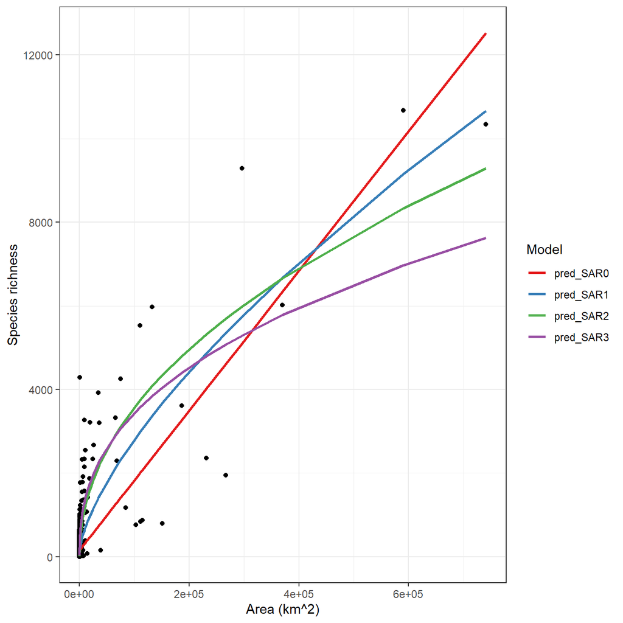

```r
# Make a data frame with all the predictions
newdata_all <- data.frame(area = islands$area,
                          log_area = islands$log_area)

newdata_all$pred_SAR0 <- as.numeric(predict(SAR0,
                                            newdata = newdata_all,
                                            type = "response"))

newdata_all$pred_SAR1 <- as.numeric(predict(SAR1,
                                            newdata = newdata_all,
                                            type = "response"))

newdata_all$pred_SAR2 <- as.numeric(predict(SAR2,
                                            newdata = newdata_all,
                                            type = "response"))
newdata_all$pred_SAR2 <- (10^newdata_all$pred_SAR2)-1

newdata_all$pred_SAR3 <- as.numeric(predict(SAR3,
                                            newdata = newdata_all,
                                            type = "response"))
# newdata_all$pred_SAR3_exp10 <- (10^newdata_all$pred_SAR3) - 1

# we also need to reverse the log-transformation for area
# newdata_all$logarea_exp10 <- (10^newdata_all$log_area)-1

# Putting the table in a long format
newdata_all <- pivot_longer(newdata_all, cols = contains("SAR"), names_to = "Model", values_to = "Predicted values")

ggplot(newdata_all, aes(area, `Predicted values`)) +
  geom_point(data = islands, aes(area, spec_num)) +
  geom_line(aes(color = Model), size = 1) +
  scale_color_brewer(palette = "Set1") +
  labs(x = "Area (km^2)", y = "Species richness") +
  theme_bw()
```

With base R, the code would be like this:

```r
plot(islands$area, islands$spec_num, xlab = "Island area (km?)",
     ylab = "Species number", main = "Species-area relationship")

# plot the simple linear model
car::regLine(SAR0, col="darkgreen")

# plot the non-linear power law model
points(newdata$area, predicted_richness_SAR1, type = "l",
       col = "darkred", lwd = 2)

# plot the log-log space model in untransformed space
newdata_SAR2 <- data.frame(log_area = log10(seq(min(islands$area),
                                                max(islands$area),
                                                length.out = 100) + 1))
predicted_richness_SAR2 <- predict(SAR2, newdata = newdata_SAR2)
points((10^newdata_SAR2$log_area) - 1, (10^predicted_richness_SAR2) - 1,
       type = "l", col = "purple", lwd = 2)
points(newdata$area, (10^predicted_richness_SAR2) - 1, type = "l",
       col = "darkgreen", lwd = 2, lty = 2)

# plot the Poisson model in untransformed space
predicted_richness_SAR3 <- predict(SAR3, newdata = newdata_SAR3,
                                   type = "response")
points((10^newdata_SAR3$log_area) - 1, predicted_richness_SAR3,
       type = "l", col="darkblue", lwd=2)
```

**How do these models compare?**

```r
AIC(SAR0, SAR1, SAR2, SAR3)
```

```
##      df        AIC
## SAR0  3  16058.205
## SAR1  3  15860.696
## SAR2  3   1796.987
## SAR3  2 158389.922
```

*Warning*: You cannot compare AIC values among models with different response variables or different distribution families. This means we can here only compare the AIC values of the first two models!

# 3. Multi-predictor model of island biodiversity

## a) Exercise II

1. Apply a log10 transformation to area, elevation, precipitation, and temperature following:  
   *Kreft, H. et al. 2008. Global diversity of island floras from a macroecological perspective. Ecology Letters 11:116-127.*
2. Simplify the geology column; change all values that are **floor** or **volcanic** to **oceanic** and afterwards set all values that are not **atoll**, **fragment**, **oceanic** or **shelf** to NA.
3. Fit a multiple linear regression to predict biodiversity patterns on islands using the following biogeographic and environmental variables: island area, distance, elevation, temperature, precipitation and island geology.
4. Use manual backward selection to specify the best model

**Hints**  
1. Remove missing observations from your data  
2. Use ‘drop1(mod, test=“F”)’  
3. Use ‘drop1(update(Multi.mod,~ . -log_max_elev), test = “F”)’

**Solutions to Exercise II**

*Transform your data*

```
## 'data.frame':    1068 obs. of  19 variables:
##  $ entity_ID       : num  1 2 3 4 5 6 7 8 9 10 ...
##  $ geo_entity      : chr  "Ashmore Reef" "Cartier Island" "Christmas Island" "Coral Sea Islands Territory" ...
##  $ longitude       : num  123 124 106 152 114 ...
##  $ latitude        : num  -12.3 -12.5 -10.5 -19 -28.5 ...
##  $ area            : num  17.836 0.0499 139.6099 3.9508 5.9764 ...
##  $ dist            : num  344.7 290.4 1309.6 315.4 59.1 ...
##  $ age_MA          : num  NA NA 20 NA NA NA NA NA NA NA ...
##  $ geology         : chr  "shelf" "shelf" "volcanic" "atoll" ...
##  $ spec_num        : num  23 1 200 21 72 7 21 1 1 2 ...
##  $ end_num         : num  0 0 15 0 NA NA NA NA NA NA ...
##  $ max_elev        : num  12 4 367 18 16 0 10 0 0 0 ...
##  $ mean_temp       : num  27.9 27.9 25.4 24 20.8 ...
##  $ mean_prec       : num  1395 1383 2178 1085 441 ...
##  $ mean_homogeneity: num  0.296 NA 0.301 NA 0.227 ...
##  $ log_area        : num  1.251 -1.302 2.145 0.597 0.776 ...
##  $ log_spec_num    : num  1.38 0.301 2.303 1.342 1.863 ...
##  $ log_max_elev    : num  1.114 0.699 2.566 1.279 1.23 ...
##  $ log_mean_prec   : num  3.14 3.14 3.34 3.04 2.64 ...
##  $ log_mean_temp   : num  1.52 1.52 1.48 1.46 1.41 ...
```

*Simplify the geology column*

```
##    atoll fragment  oceanic    shelf     NA's
##       88       86      277      272      345
```

*Fit multiple regression model*

```
## [1] "dist"          "geology"       "log_area"      "log_spec_num"
## [5] "log_max_elev"  "log_mean_prec" "log_mean_temp"
```

```
##
## Call:
## lm(formula = log_spec_num ~ log_area + dist + log_max_elev +
##     log_mean_temp + log_mean_prec + geology, data = new_islands)
##
## Residuals:
##      Min       1Q   Median       3Q      Max
## -1.16507 -0.17425  0.01397  0.21620  0.78886
##
## Coefficients:
##                   Estimate Std. Error t value Pr(>|t|)
## (Intercept)     -8.610e-01  1.594e-01  -5.401 9.39e-08 ***
## log_area         3.190e-01  1.192e-02  26.766  < 2e-16 ***
## dist            -1.190e-04  1.027e-05 -11.589  < 2e-16 ***
## log_max_elev     1.185e-01  2.328e-02   5.092 4.67e-07 ***
## log_mean_temp    8.467e-01  6.948e-02  12.187  < 2e-16 ***
## log_mean_prec    3.377e-01  3.669e-02   9.202  < 2e-16 ***
## geologyfragment  2.099e-01  5.517e-02   3.804 0.000156 ***
## geologyoceanic   1.347e-01  4.659e-02   2.892 0.003958 **
## geologyshelf     3.488e-01  5.213e-02   6.692 4.85e-11 ***
## ---
## Signif. codes:  0 '***' 0.001 '**' 0.01 '*' 0.05 '.' 0.1 ' ' 1
##
## Residual standard error: 0.3042 on 636 degrees of freedom
## Multiple R-squared:  0.8248, Adjusted R-squared:  0.8226
## F-statistic: 374.4 on 8 and 636 DF,  p-value: < 2.2e-16
```

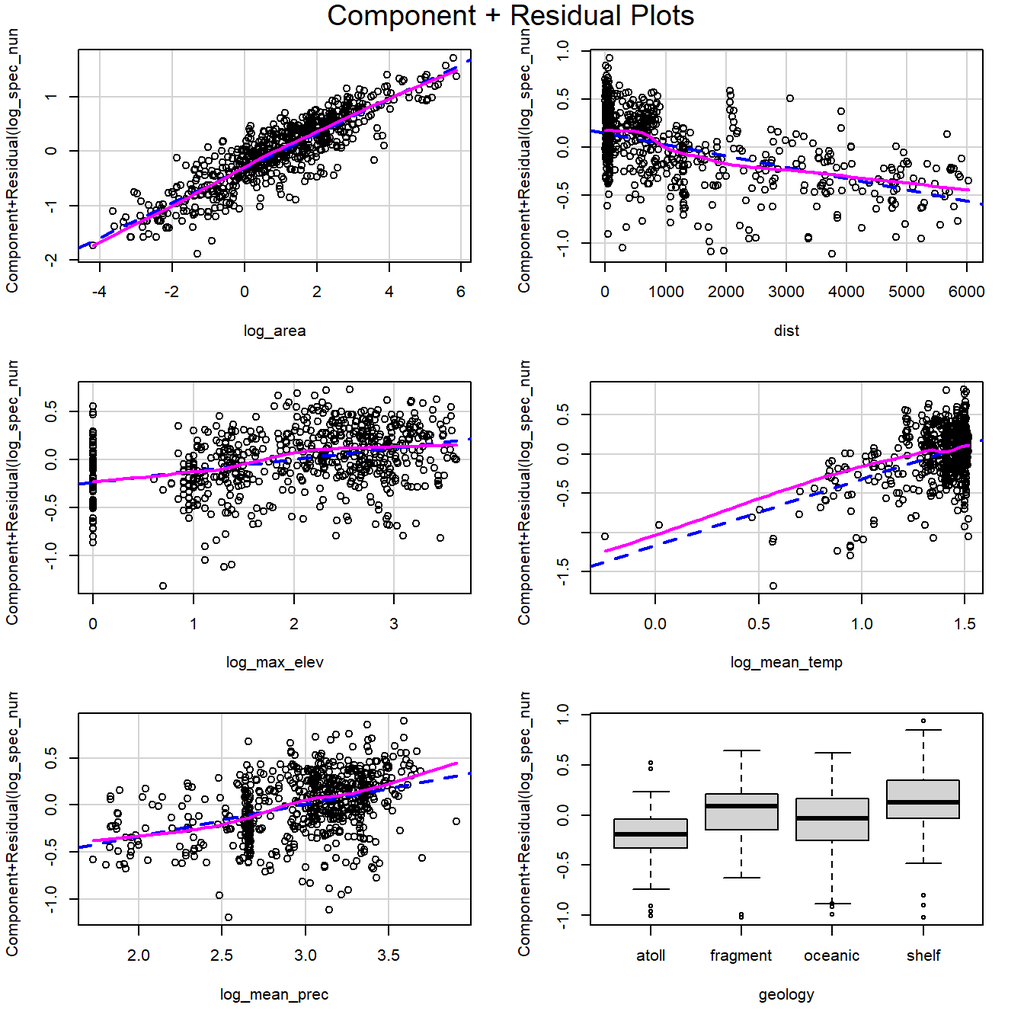

*Can we improve predictions of species richness by removing individual model terms?*

```
##            df      AIC
## Multi.mod  10 305.9918
## Multi.mod1  9 329.7655
```

# 4. The General dynamic model of island biogeography (GDM)

```r
# Assign archipelago names for 4 major archipelagos
islands$archipelago <- NA
islands$archipelago[which(islands$entity_ID %in% c(169:188))] <- "Hawaii"
islands$archipelago[which(islands$entity_ID %in% c(145:151))] <- "Canaries"
islands$archipelago[which(islands$entity_ID %in% c(154:168))] <- "Galapagos"
islands$archipelago[which(islands$entity_ID %in% c(131:139))] <- "Azores"
islands_gdm <- islands[!is.na(islands$archipelago),]

# Log-transforming age
islands_gdm$log_age_MA <- log10(islands_gdm$age_MA)
```

**The General dynamic model of island biogeography (GDM) applied: just Hawaii (part I)**

*Species = Area x Time x Time<sup>2</sup>*

```r
# subset data
Hawaii <- islands_gdm[which(islands_gdm$archipelago == "Hawaii"), ]

# The ATT^2 model
gdm1 <- lm(spec_num ~ log_area + age_MA + I(age_MA^2), data = Hawaii)
summary(gdm1)
```

```
##
## Call:
## lm(formula = spec_num ~ log_area + age_MA + I(age_MA^2), data = Hawaii)
##
## Residuals:
##      Min       1Q   Median       3Q      Max
## -186.217  -36.257   -7.487   54.782  132.712
##
## Coefficients:
##             Estimate Std. Error t value Pr(>|t|)
## (Intercept)  17.8573    75.5422   0.236    0.817
## log_area    101.6453    18.4843   5.499 7.84e-05 ***
## age_MA        6.9123    14.9556   0.462    0.651
## I(age_MA^2)  -0.3382     0.5654  -0.598    0.559
## ---
## Signif. codes:  0 '***' 0.001 '**' 0.01 '*' 0.05 '.' 0.1 ' ' 1
##
## Residual standard error: 99.95 on 14 degrees of freedom
##   (1 observation deleted due to missingness)
## Multiple R-squared:  0.7819, Adjusted R-squared:  0.7352
## F-statistic: 16.74 on 3 and 14 DF,  p-value: 6.624e-05
```

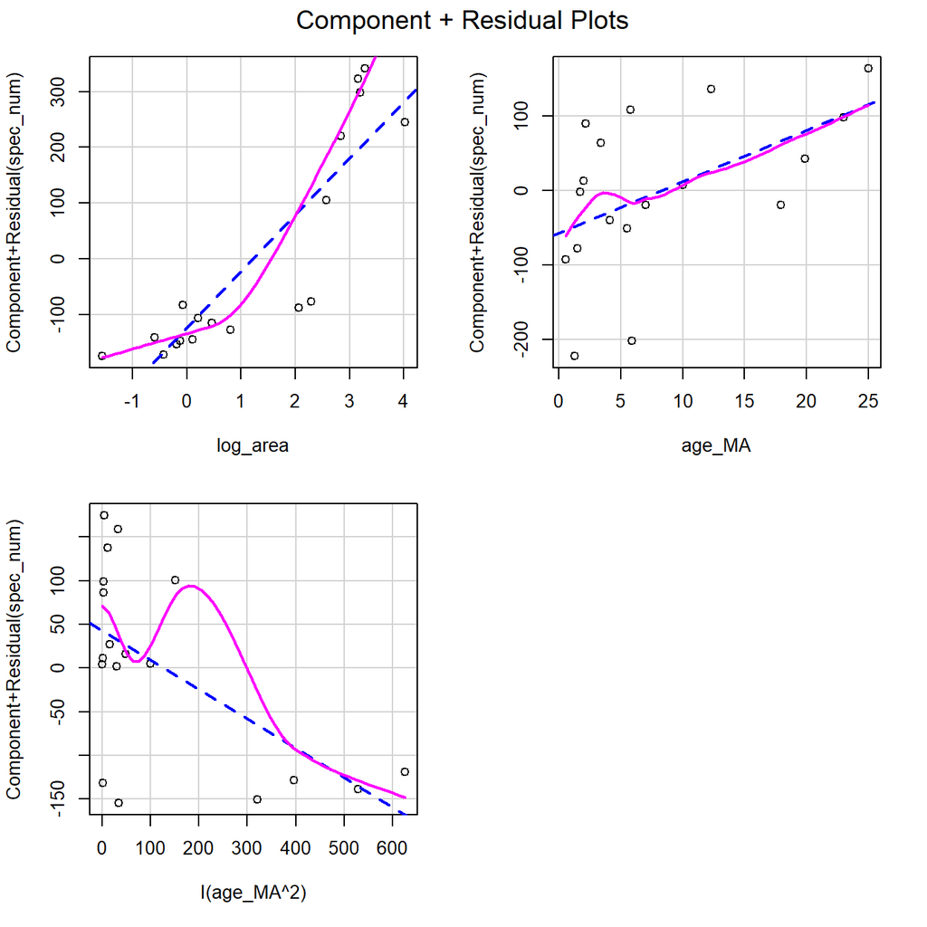

```r
crPlots(gdm1)
```

**The General dynamic model of island biogeography (GDM) applied: just Hawaii (part II)**

*Species = log(Area) x log(Time) x log(Time)<sup>2</sup>*

```r
gdm2 <- lm(spec_num ~ log_area + log_age_MA + I(log_age_MA^2), data = Hawaii)
summary(gdm2)
```

```
##
## Call:
## lm(formula = spec_num ~ log_area + log_age_MA + I(log_age_MA^2),
##     data = Hawaii)
##
## Residuals:
##      Min       1Q   Median       3Q      Max
## -202.253  -32.019    0.423   44.757  129.135
##
## Coefficients:
##                 Estimate Std. Error t value Pr(>|t|)
## (Intercept)       -5.993     67.654  -0.089    0.931
## log_area         104.969     17.780   5.904 3.84e-05 ***
## log_age_MA       178.602    146.703   1.217    0.244
## I(log_age_MA^2) -128.441     99.082  -1.296    0.216
## ---
## Signif. codes:  0 '***' 0.001 '**' 0.01 '*' 0.05 '.' 0.1 ' ' 1
##
## Residual standard error: 96.45 on 14 degrees of freedom
##   (1 observation deleted due to missingness)
## Multiple R-squared:  0.797,  Adjusted R-squared:  0.7534
## F-statistic: 18.32 on 3 and 14 DF,  p-value: 4.054e-05
```

```r
AIC(gdm1, gdm2)
```

```
##      df      AIC
## gdm1  5 222.3272
## gdm2  5 221.0441
```

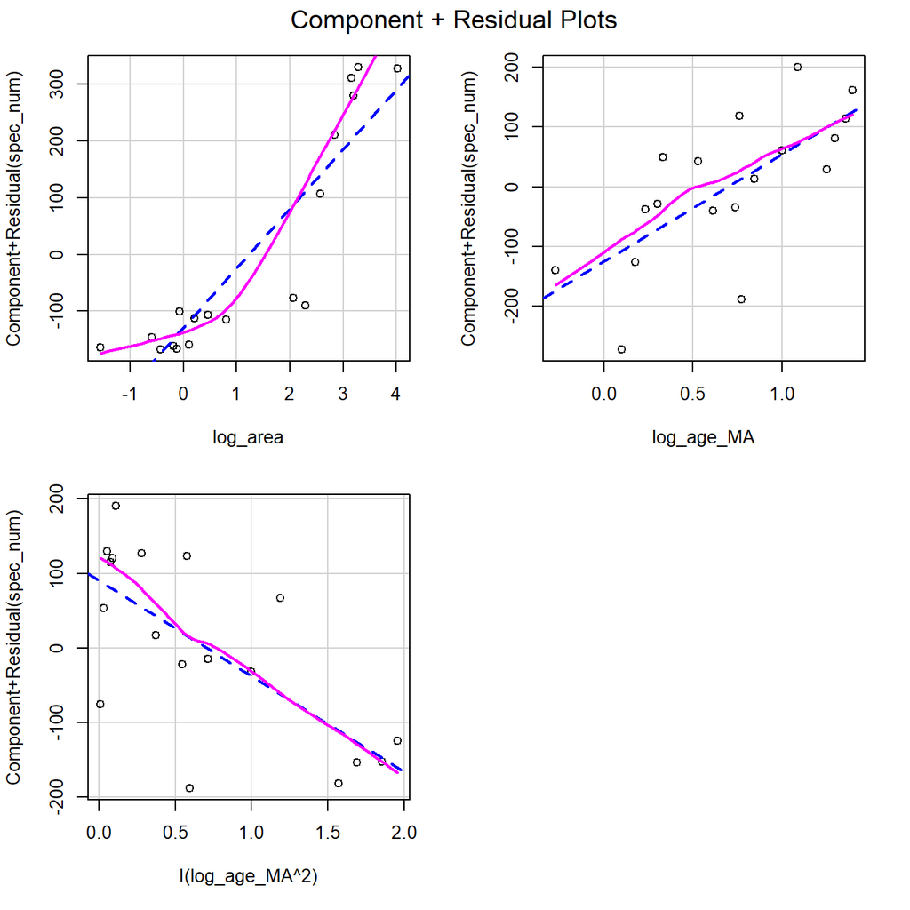

```r
crPlots(gdm2)
```

**A linear mixed effects model for all 4 archipelagos**

*Species = log(Area) + log(Time) + log(Time)<sup>2</sup> + (1|archipelago)*

```r
gdm_all <- lme4::glmer(spec_num ~ log_area + log_age_MA + I(log_age_MA^2) +
                         (1|archipelago), data = islands_gdm, family = poisson)
summary(gdm_all)
```

```
## Generalized linear mixed model fit by maximum likelihood (Laplace
##   Approximation) [glmerMod]
##  Family: poisson  ( log )
## Formula: spec_num ~ log_area + log_age_MA + I(log_age_MA^2) + (1 | archipelago)
##    Data: islands_gdm
##
##      AIC      BIC   logLik deviance df.resid
##   1061.6   1070.9   -525.8   1051.6       43
##
## Scaled residuals:
##     Min      1Q  Median      3Q     Max
## -7.2215 -2.5559 -0.9946  2.9694  6.9950
##
## Random effects:
##  Groups      Name        Variance Std.Dev.
##  archipelago (Intercept) 0.2331   0.4828
## Number of obs: 48, groups:  archipelago, 4
##
## Fixed effects:
##                 Estimate Std. Error z value Pr(>|z|)
## (Intercept)      3.63903    0.24484   14.86   <2e-16 ***
## log_area         0.76793    0.01397   54.96   <2e-16 ***
## log_age_MA       0.62899    0.04339   14.50   <2e-16 ***
## I(log_age_MA^2) -0.64479    0.03853  -16.73   <2e-16 ***
## ---
## Signif. codes:  0 '***' 0.001 '**' 0.01 '*' 0.05 '.' 0.1 ' ' 1
##
## Correlation of Fixed Effects:
##             (Intr) log_ar lg__MA
## log_area    -0.158
## log_age_MA  -0.036  0.141
## I(lg__MA^2)  0.009 -0.091 -0.855
```

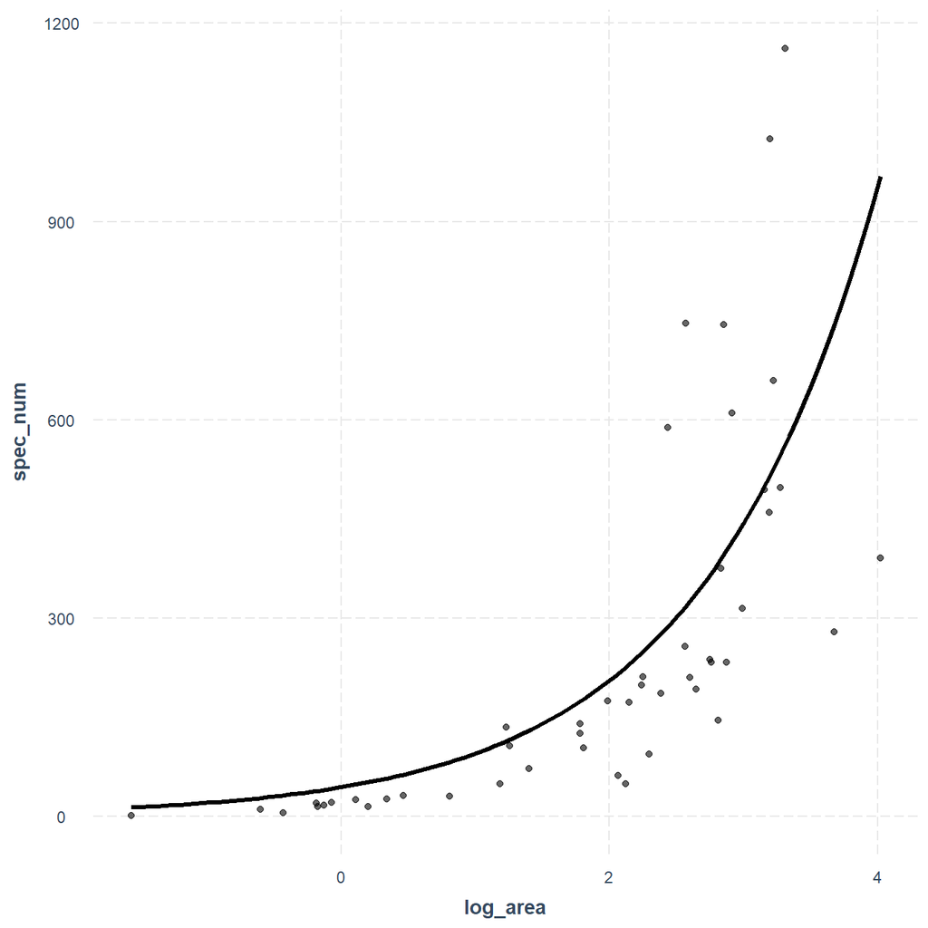

```r
effect_plot(gdm_all, pred = "log_area", outcome.scale = "response", plot.points = TRUE)
```

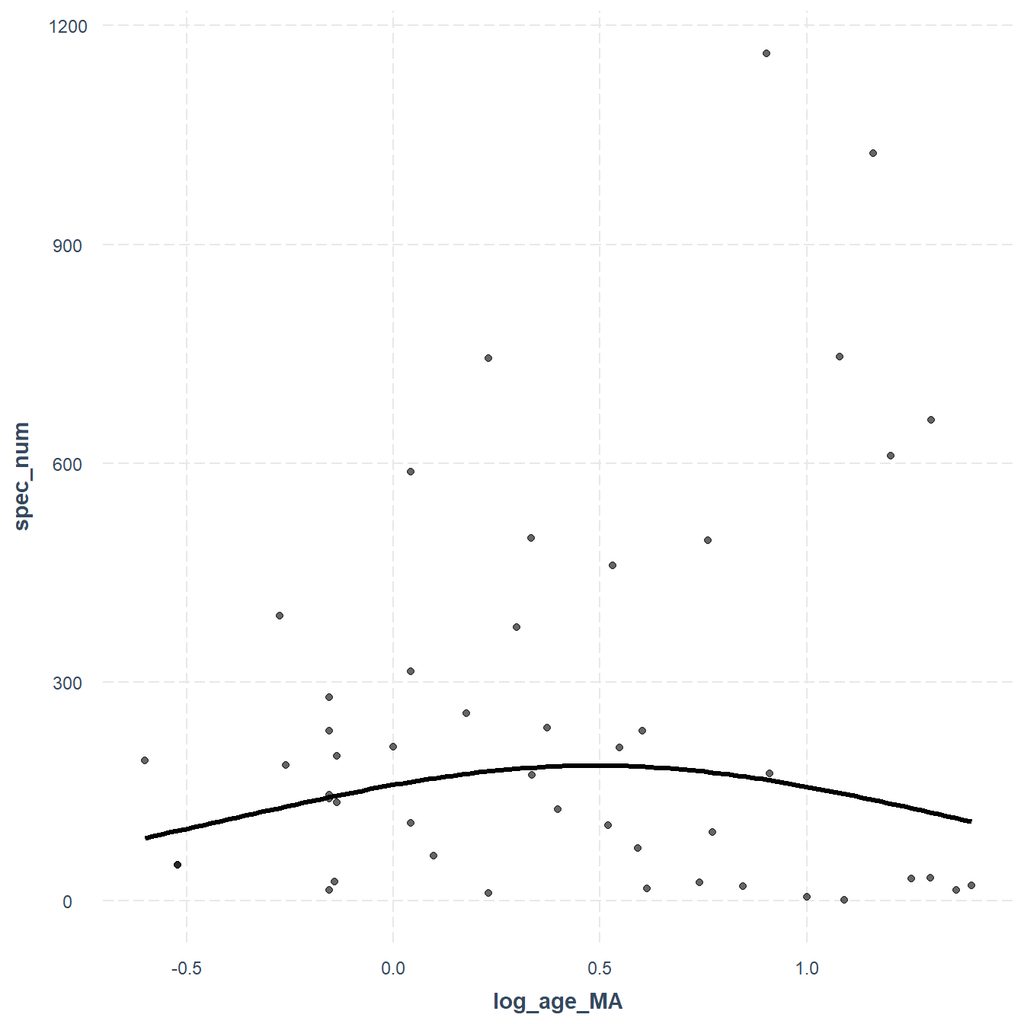

```r
effect_plot(gdm_all, pred = "log_age_MA", outcome.scale = "response", plot.points = TRUE)
```

```r
model_performance(gdm_all, metrics = "common")
```

```
## # Indices of model performance
##
## AIC      |      BIC | R2 (cond.) | R2 (marg.) |   ICC |   RMSE
## --------------------------------------------------------------
## 1061.567 | 1070.923 |      0.997 |      0.823 | 0.982 | 65.521
```